# Risk Factor Analysis

## Outcome Variable

**Outcome Variable:** ever_wasted

## Predictor Variables

**Intervention Variable:** sex

**Adjustment Set:**

unadjusted

## Stratifying Variables

The analysis was stratified on these variable(s):

- agecat
- studyid
- country

## Data Summary

| agecat | studyid | country | sex | ever_wasted | n_cell | n |
| --- | --- | --- | --- | --- | --- | --- |
| 0-24 months | CMC-V-BCS-2002 | INDIA | Female | 0 | 70 | 373 |
| 0-24 months | CMC-V-BCS-2002 | INDIA | Female | 1 | 117 | 373 |
| 0-24 months | CMC-V-BCS-2002 | INDIA | Male | 0 | 75 | 373 |
| 0-24 months | CMC-V-BCS-2002 | INDIA | Male | 1 | 111 | 373 |
| 0-24 months | CMIN | BANGLADESH | Female | 0 | 64 | 272 |
| 0-24 months | CMIN | BANGLADESH | Female | 1 | 55 | 272 |
| 0-24 months | CMIN | BANGLADESH | Male | 0 | 84 | 272 |
| 0-24 months | CMIN | BANGLADESH | Male | 1 | 69 | 272 |
| 0-24 months | COHORTS | GUATEMALA | Female | 0 | 506 | 1349 |
| 0-24 months | COHORTS | GUATEMALA | Female | 1 | 129 | 1349 |
| 0-24 months | COHORTS | GUATEMALA | Male | 0 | 500 | 1349 |
| 0-24 months | COHORTS | GUATEMALA | Male | 1 | 214 | 1349 |
| 0-24 months | COHORTS | INDIA | Female | 0 | 2389 | 7405 |
| 0-24 months | COHORTS | INDIA | Female | 1 | 1162 | 7405 |
| 0-24 months | COHORTS | INDIA | Male | 0 | 2571 | 7405 |
| 0-24 months | COHORTS | INDIA | Male | 1 | 1283 | 7405 |
| 0-24 months | COHORTS | PHILIPPINES | Female | 0 | 883 | 3045 |
| 0-24 months | COHORTS | PHILIPPINES | Female | 1 | 548 | 3045 |
| 0-24 months | COHORTS | PHILIPPINES | Male | 0 | 933 | 3045 |
| 0-24 months | COHORTS | PHILIPPINES | Male | 1 | 681 | 3045 |
| 0-24 months | CONTENT | PERU | Female | 0 | 107 | 215 |
| 0-24 months | CONTENT | PERU | Female | 1 | 2 | 215 |
| 0-24 months | CONTENT | PERU | Male | 0 | 103 | 215 |
| 0-24 months | CONTENT | PERU | Male | 1 | 3 | 215 |
| 0-24 months | EE | PAKISTAN | Female | 0 | 78 | 380 |
| 0-24 months | EE | PAKISTAN | Female | 1 | 107 | 380 |
| 0-24 months | EE | PAKISTAN | Male | 0 | 76 | 380 |
| 0-24 months | EE | PAKISTAN | Male | 1 | 119 | 380 |
| 0-24 months | GMS-Nepal | NEPAL | Female | 0 | 126 | 686 |
| 0-24 months | GMS-Nepal | NEPAL | Female | 1 | 196 | 686 |

[output cut: 314 more lines]

The following strata were considered:

- agecat: 0-24 months, studyid: CMC-V-BCS-2002, country: INDIA
- agecat: 0-24 months, studyid: CMIN, country: BANGLADESH
- agecat: 0-24 months, studyid: COHORTS, country: GUATEMALA
- agecat: 0-24 months, studyid: COHORTS, country: INDIA
- agecat: 0-24 months, studyid: COHORTS, country: PHILIPPINES
- agecat: 0-24 months, studyid: CONTENT, country: PERU
- agecat: 0-24 months, studyid: EE, country: PAKISTAN
- agecat: 0-24 months, studyid: GMS-Nepal, country: NEPAL
- agecat: 0-24 months, studyid: Guatemala BSC, country: GUATEMALA
- agecat: 0-24 months, studyid: iLiNS-Zinc, country: BURKINA FASO
- agecat: 0-24 months, studyid: IRC, country: INDIA
- agecat: 0-24 months, studyid: Keneba, country: GAMBIA
- agecat: 0-24 months, studyid: LCNI-5, country: MALAWI
- agecat: 0-24 months, studyid: MAL-ED, country: BANGLADESH
- agecat: 0-24 months, studyid: MAL-ED, country: BRAZIL
- agecat: 0-24 months, studyid: MAL-ED, country: INDIA
- agecat: 0-24 months, studyid: MAL-ED, country: NEPAL
- agecat: 0-24 months, studyid: MAL-ED, country: PERU
- agecat: 0-24 months, studyid: MAL-ED, country: SOUTH AFRICA
- agecat: 0-24 months, studyid: MAL-ED, country: TANZANIA, UNITED REPUBLIC OF
- agecat: 0-24 months, studyid: NIH-Birth, country: BANGLADESH
- agecat: 0-24 months, studyid: NIH-Crypto, country: BANGLADESH
- agecat: 0-24 months, studyid: PROBIT, country: BELARUS
- agecat: 0-24 months, studyid: PROVIDE, country: BANGLADESH
- agecat: 0-24 months, studyid: ResPak, country: PAKISTAN
- agecat: 0-24 months, studyid: SAS-CompFeed, country: INDIA
- agecat: 0-24 months, studyid: SAS-FoodSuppl, country: INDIA
- agecat: 0-24 months, studyid: TanzaniaChild2, country: TANZANIA, UNITED REPUBLIC OF
- agecat: 0-24 months, studyid: ZVITAMBO, country: ZIMBABWE
- agecat: 0-6 months, studyid: CMC-V-BCS-2002, country: INDIA
- agecat: 0-6 months, studyid: CMIN, country: BANGLADESH
- agecat: 0-6 months, studyid: COHORTS, country: GUATEMALA
- agecat: 0-6 months, studyid: COHORTS, country: INDIA
- agecat: 0-6 months, studyid: COHORTS, country: PHILIPPINES
- agecat: 0-6 months, studyid: CONTENT, country: PERU
- agecat: 0-6 months, studyid: EE, country: PAKISTAN
- agecat: 0-6 months, studyid: GMS-Nepal, country: NEPAL
- agecat: 0-6 months, studyid: Guatemala BSC, country: GUATEMALA
- agecat: 0-6 months, studyid: IRC, country: INDIA
- agecat: 0-6 months, studyid: Keneba, country: GAMBIA
- agecat: 0-6 months, studyid: LCNI-5, country: MALAWI
- agecat: 0-6 months, studyid: MAL-ED, country: BANGLADESH
- agecat: 0-6 months, studyid: MAL-ED, country: BRAZIL
- agecat: 0-6 months, studyid: MAL-ED, country: INDIA
- agecat: 0-6 months, studyid: MAL-ED, country: NEPAL
- agecat: 0-6 months, studyid: MAL-ED, country: PERU
- agecat: 0-6 months, studyid: MAL-ED, country: SOUTH AFRICA
- agecat: 0-6 months, studyid: MAL-ED, country: TANZANIA, UNITED REPUBLIC OF
- agecat: 0-6 months, studyid: NIH-Birth, country: BANGLADESH
- agecat: 0-6 months, studyid: NIH-Crypto, country: BANGLADESH
- agecat: 0-6 months, studyid: PROBIT, country: BELARUS
- agecat: 0-6 months, studyid: PROVIDE, country: BANGLADESH
- agecat: 0-6 months, studyid: ResPak, country: PAKISTAN
- agecat: 0-6 months, studyid: SAS-CompFeed, country: INDIA
- agecat: 0-6 months, studyid: SAS-FoodSuppl, country: INDIA
- agecat: 0-6 months, studyid: TanzaniaChild2, country: TANZANIA, UNITED REPUBLIC OF
- agecat: 0-6 months, studyid: ZVITAMBO, country: ZIMBABWE
- agecat: 6-24 months, studyid: CMC-V-BCS-2002, country: INDIA
- agecat: 6-24 months, studyid: CMIN, country: BANGLADESH
- agecat: 6-24 months, studyid: COHORTS, country: GUATEMALA
- agecat: 6-24 months, studyid: COHORTS, country: INDIA
- agecat: 6-24 months, studyid: COHORTS, country: PHILIPPINES
- agecat: 6-24 months, studyid: CONTENT, country: PERU
- agecat: 6-24 months, studyid: EE, country: PAKISTAN
- agecat: 6-24 months, studyid: GMS-Nepal, country: NEPAL
- agecat: 6-24 months, studyid: Guatemala BSC, country: GUATEMALA
- agecat: 6-24 months, studyid: iLiNS-Zinc, country: BURKINA FASO
- agecat: 6-24 months, studyid: IRC, country: INDIA
- agecat: 6-24 months, studyid: Keneba, country: GAMBIA
- agecat: 6-24 months, studyid: LCNI-5, country: MALAWI
- agecat: 6-24 months, studyid: MAL-ED, country: BANGLADESH
- agecat: 6-24 months, studyid: MAL-ED, country: BRAZIL
- agecat: 6-24 months, studyid: MAL-ED, country: INDIA
- agecat: 6-24 months, studyid: MAL-ED, country: NEPAL
- agecat: 6-24 months, studyid: MAL-ED, country: PERU
- agecat: 6-24 months, studyid: MAL-ED, country: SOUTH AFRICA
- agecat: 6-24 months, studyid: MAL-ED, country: TANZANIA, UNITED REPUBLIC OF
- agecat: 6-24 months, studyid: NIH-Birth, country: BANGLADESH
- agecat: 6-24 months, studyid: NIH-Crypto, country: BANGLADESH
- agecat: 6-24 months, studyid: PROBIT, country: BELARUS
- agecat: 6-24 months, studyid: PROVIDE, country: BANGLADESH
- agecat: 6-24 months, studyid: ResPak, country: PAKISTAN
- agecat: 6-24 months, studyid: SAS-CompFeed, country: INDIA
- agecat: 6-24 months, studyid: SAS-FoodSuppl, country: INDIA
- agecat: 6-24 months, studyid: TanzaniaChild2, country: TANZANIA, UNITED REPUBLIC OF
- agecat: 6-24 months, studyid: ZVITAMBO, country: ZIMBABWE

### Dropped Strata

Some strata were dropped due to rare outcomes:

- agecat: 0-24 months, studyid: CONTENT, country: PERU
- agecat: 0-6 months, studyid: CONTENT, country: PERU
- agecat: 0-6 months, studyid: Guatemala BSC, country: GUATEMALA
- agecat: 0-6 months, studyid: LCNI-5, country: MALAWI
- agecat: 0-6 months, studyid: MAL-ED, country: PERU
- agecat: 0-6 months, studyid: MAL-ED, country: TANZANIA, UNITED REPUBLIC OF
- agecat: 6-24 months, studyid: CONTENT, country: PERU
- agecat: 6-24 months, studyid: MAL-ED, country: BRAZIL

## Methods Detail

We’re interested in the causal parameters $E[Y_a]$ for all values of $a \in \mathcal{A}$. These parameters represent the mean outcome if, possibly contrary to fact, we intervened to set all units to have $A=a$. Under the randomization and positivity assumptions, these are identified by the statistical parameters $\psi_a=E_W[E_{Y|A,W}(Y|A=a,W)]$. In addition, we’re interested in the mean of $Y$, $E[Y]$ under no intervention (the observed mean). We will estimate these parameters by using SuperLearner to fit the relevant likelihood factors – $E_{Y|A,W}(Y|A=a,W)$ and $p(A=a|W)$, and then updating our likelihood fit using a joint TMLE.

For unadjusted analyses ($W=\{\}$), initial likelihoods were estimated using Lrnr_glm to estimate the simple $E(Y|A)$ and Lrnr_mean to estimate $p(A)$. For adjusted analyses, a small library containing Lrnr_glmnet, Lrnr_xgboost, and Lrnr_mean was used.

Having estimated these parameters, we will then use the delta method to estimate relative risks and attributable risks relative to a prespecified baseline level of $A$.

# Results Detail

## Results Plots

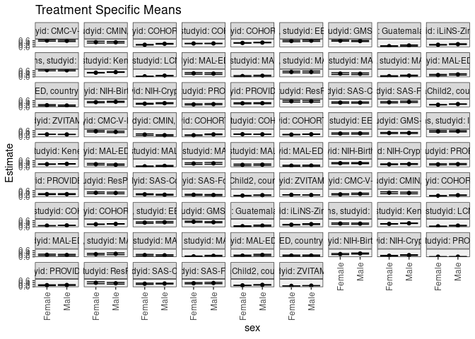

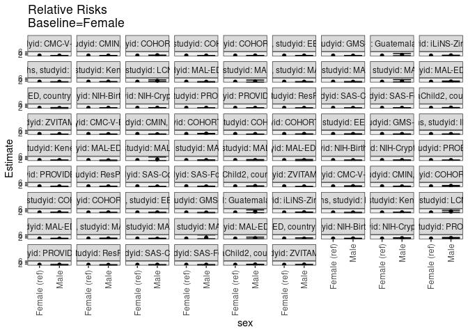

[figure not shown]

[figure not shown]

## Results Table

### Parameter: TSM

| agecat | studyid | country | intervention_level | baseline_level | estimate | ci_lower | ci_upper |
| --- | --- | --- | --- | --- | --- | --- | --- |
| 0-24 months | CMC-V-BCS-2002 | INDIA | Female | NA | 0.6256684 | 0.5562123 | 0.6951246 |
| 0-24 months | CMC-V-BCS-2002 | INDIA | Male | NA | 0.5967742 | 0.5261825 | 0.6673659 |
| 0-24 months | CMIN | BANGLADESH | Female | NA | 0.4621849 | 0.3724422 | 0.5519275 |
| 0-24 months | CMIN | BANGLADESH | Male | NA | 0.4509804 | 0.3719899 | 0.5299709 |
| 0-24 months | COHORTS | GUATEMALA | Female | NA | 0.2031496 | 0.1718443 | 0.2344550 |
| 0-24 months | COHORTS | GUATEMALA | Male | NA | 0.2997199 | 0.2661033 | 0.3333365 |
| 0-24 months | COHORTS | INDIA | Female | NA | 0.3272318 | 0.3117983 | 0.3426652 |
| 0-24 months | COHORTS | INDIA | Male | NA | 0.3329009 | 0.3180219 | 0.3477799 |
| 0-24 months | COHORTS | PHILIPPINES | Female | NA | 0.3829490 | 0.3577588 | 0.4081391 |
| 0-24 months | COHORTS | PHILIPPINES | Male | NA | 0.4219331 | 0.3978352 | 0.4460309 |
| 0-24 months | EE | PAKISTAN | Female | NA | 0.5783784 | 0.5071256 | 0.6496312 |
| 0-24 months | EE | PAKISTAN | Male | NA | 0.6102564 | 0.5417157 | 0.6787971 |
| 0-24 months | GMS-Nepal | NEPAL | Female | NA | 0.6086957 | 0.5553506 | 0.6620407 |
| 0-24 months | GMS-Nepal | NEPAL | Male | NA | 0.5741758 | 0.5233421 | 0.6250095 |
| 0-24 months | Guatemala BSC | GUATEMALA | Female | NA | 0.0679012 | 0.0290995 | 0.1067029 |
| 0-24 months | Guatemala BSC | GUATEMALA | Male | NA | 0.1307190 | 0.0772204 | 0.1842175 |
| 0-24 months | iLiNS-Zinc | BURKINA FASO | Female | NA | 0.2030769 | 0.1735252 | 0.2326286 |
| 0-24 months | iLiNS-Zinc | BURKINA FASO | Male | NA | 0.2602072 | 0.2146739 | 0.3057404 |
| 0-24 months | IRC | INDIA | Female | NA | 0.6648649 | 0.5967614 | 0.7329683 |
| 0-24 months | IRC | INDIA | Male | NA | 0.6488889 | 0.5864443 | 0.7113334 |
| 0-24 months | Keneba | GAMBIA | Female | NA | 0.4075124 | 0.3818694 | 0.4331554 |
| 0-24 months | Keneba | GAMBIA | Male | NA | 0.4658714 | 0.4406985 | 0.4910444 |
| 0-24 months | LCNI-5 | MALAWI | Female | NA | 0.0498812 | 0.0290736 | 0.0706889 |
| 0-24 months | LCNI-5 | MALAWI | Male | NA | 0.1097852 | 0.0798337 | 0.1397367 |
| 0-24 months | MAL-ED | BANGLADESH | Female | NA | 0.3432836 | 0.2627386 | 0.4238285 |
| 0-24 months | MAL-ED | BANGLADESH | Male | NA | 0.3178295 | 0.2373242 | 0.3983347 |
| 0-24 months | MAL-ED | BRAZIL | Female | NA | 0.0707965 | 0.0234046 | 0.1181884 |
| 0-24 months | MAL-ED | BRAZIL | Male | NA | 0.1000000 | 0.0462086 | 0.1537914 |
| 0-24 months | MAL-ED | INDIA | Female | NA | 0.4782609 | 0.3947516 | 0.5617701 |
| 0-24 months | MAL-ED | INDIA | Male | NA | 0.4778761 | 0.3855934 | 0.5701588 |

[output cut: 126 more lines]

### Parameter: E(Y)

| agecat | studyid | country | intervention_level | baseline_level | estimate | ci_lower | ci_upper |
| --- | --- | --- | --- | --- | --- | --- | --- |
| 0-24 months | CMC-V-BCS-2002 | INDIA | NA | NA | 0.6112601 | 0.5617242 | 0.6607959 |
| 0-24 months | CMIN | BANGLADESH | NA | NA | 0.4558824 | 0.3965849 | 0.5151798 |
| 0-24 months | COHORTS | GUATEMALA | NA | NA | 0.2542624 | 0.2310170 | 0.2775078 |
| 0-24 months | COHORTS | INDIA | NA | NA | 0.3301823 | 0.3194703 | 0.3408943 |
| 0-24 months | COHORTS | PHILIPPINES | NA | NA | 0.4036125 | 0.3861835 | 0.4210415 |
| 0-24 months | EE | PAKISTAN | NA | NA | 0.5947368 | 0.5453104 | 0.6441633 |
| 0-24 months | GMS-Nepal | NEPAL | NA | NA | 0.5903790 | 0.5535526 | 0.6272054 |
| 0-24 months | Guatemala BSC | GUATEMALA | NA | NA | 0.0984127 | 0.0654659 | 0.1313595 |
| 0-24 months | iLiNS-Zinc | BURKINA FASO | NA | NA | 0.2317820 | 0.2038933 | 0.2596707 |
| 0-24 months | IRC | INDIA | NA | NA | 0.6560976 | 0.6100625 | 0.7021326 |
| 0-24 months | Keneba | GAMBIA | NA | NA | 0.4376712 | 0.4196742 | 0.4556682 |
| 0-24 months | LCNI-5 | MALAWI | NA | NA | 0.0797619 | 0.0614297 | 0.0980941 |
| 0-24 months | MAL-ED | BANGLADESH | NA | NA | 0.3307985 | 0.2738270 | 0.3877700 |
| 0-24 months | MAL-ED | BRAZIL | NA | NA | 0.0858369 | 0.0497913 | 0.1218826 |
| 0-24 months | MAL-ED | INDIA | NA | NA | 0.4780876 | 0.4161677 | 0.5400076 |
| 0-24 months | MAL-ED | NEPAL | NA | NA | 0.3083333 | 0.2497859 | 0.3668808 |
| 0-24 months | MAL-ED | PERU | NA | NA | 0.0894040 | 0.0571706 | 0.1216374 |
| 0-24 months | MAL-ED | SOUTH AFRICA | NA | NA | 0.2051282 | 0.1602507 | 0.2500058 |
| 0-24 months | MAL-ED | TANZANIA, UNITED REPUBLIC OF | NA | NA | 0.1379310 | 0.0960166 | 0.1798455 |
| 0-24 months | NIH-Birth | BANGLADESH | NA | NA | 0.4775641 | 0.4383415 | 0.5167867 |
| 0-24 months | NIH-Crypto | BANGLADESH | NA | NA | 0.3298153 | 0.2963239 | 0.3633067 |
| 0-24 months | PROBIT | BELARUS | NA | NA | 0.2554148 | 0.1971257 | 0.3137039 |
| 0-24 months | PROVIDE | BANGLADESH | NA | NA | 0.3514286 | 0.3160364 | 0.3868207 |
| 0-24 months | ResPak | PAKISTAN | NA | NA | 0.5492958 | 0.4913257 | 0.6072658 |
| 0-24 months | SAS-CompFeed | INDIA | NA | NA | 0.4150694 | 0.3581204 | 0.4720184 |
| 0-24 months | SAS-FoodSuppl | INDIA | NA | NA | 0.4712919 | 0.4233811 | 0.5192026 |
| 0-24 months | TanzaniaChild2 | TANZANIA, UNITED REPUBLIC OF | NA | NA | 0.2362270 | 0.2192156 | 0.2532385 |
| 0-24 months | ZVITAMBO | ZIMBABWE | NA | NA | 0.2366987 | 0.2296439 | 0.2437535 |
| 0-6 months | CMC-V-BCS-2002 | INDIA | NA | NA | 0.5163043 | 0.4651769 | 0.5674318 |
| 0-6 months | CMIN | BANGLADESH | NA | NA | 0.1838235 | 0.1377071 | 0.2299400 |
| 0-6 months | COHORTS | GUATEMALA | NA | NA | 0.2011278 | 0.1770312 | 0.2252244 |
| 0-6 months | COHORTS | INDIA | NA | NA | 0.2519641 | 0.2418849 | 0.2620433 |
| 0-6 months | COHORTS | PHILIPPINES | NA | NA | 0.2355453 | 0.2204685 | 0.2506222 |
| 0-6 months | EE | PAKISTAN | NA | NA | 0.3263158 | 0.2791121 | 0.3735195 |
| 0-6 months | GMS-Nepal | NEPAL | NA | NA | 0.3760933 | 0.3398180 | 0.4123685 |
| 0-6 months | IRC | INDIA | NA | NA | 0.5439024 | 0.4956326 | 0.5921723 |
| 0-6 months | Keneba | GAMBIA | NA | NA | 0.2733171 | 0.2557239 | 0.2909103 |
| 0-6 months | MAL-ED | BANGLADESH | NA | NA | 0.2281369 | 0.1773250 | 0.2789488 |
| 0-6 months | MAL-ED | BRAZIL | NA | NA | 0.0643777 | 0.0327970 | 0.0959584 |
| 0-6 months | MAL-ED | INDIA | NA | NA | 0.3266932 | 0.2685560 | 0.3848305 |
| 0-6 months | MAL-ED | NEPAL | NA | NA | 0.2000000 | 0.1492882 | 0.2507118 |
| 0-6 months | MAL-ED | SOUTH AFRICA | NA | NA | 0.1121795 | 0.0771053 | 0.1472536 |
| 0-6 months | NIH-Birth | BANGLADESH | NA | NA | 0.3569132 | 0.3192325 | 0.3945938 |
| 0-6 months | NIH-Crypto | BANGLADESH | NA | NA | 0.2572559 | 0.2261171 | 0.2883948 |
| 0-6 months | PROBIT | BELARUS | NA | NA | 0.2500148 | 0.1915461 | 0.3084835 |
| 0-6 months | PROVIDE | BANGLADESH | NA | NA | 0.2585714 | 0.2261125 | 0.2910304 |
| 0-6 months | ResPak | PAKISTAN | NA | NA | 0.3865248 | 0.3295895 | 0.4434602 |
| 0-6 months | SAS-CompFeed | INDIA | NA | NA | 0.2199336 | 0.1753445 | 0.2645227 |
| 0-6 months | SAS-FoodSuppl | INDIA | NA | NA | 0.1866029 | 0.1492099 | 0.2239959 |
| 0-6 months | TanzaniaChild2 | TANZANIA, UNITED REPUBLIC OF | NA | NA | 0.1389816 | 0.1251275 | 0.1528358 |
| 0-6 months | ZVITAMBO | ZIMBABWE | NA | NA | 0.1811160 | 0.1747027 | 0.1875293 |
| 6-24 months | CMC-V-BCS-2002 | INDIA | NA | NA | 0.2654155 | 0.2205451 | 0.3102860 |
| 6-24 months | CMIN | BANGLADESH | NA | NA | 0.3849206 | 0.3247254 | 0.4451159 |
| 6-24 months | COHORTS | GUATEMALA | NA | NA | 0.1262295 | 0.1075861 | 0.1448729 |
| 6-24 months | COHORTS | INDIA | NA | NA | 0.1226048 | 0.1148883 | 0.1303213 |
| 6-24 months | COHORTS | PHILIPPINES | NA | NA | 0.2666429 | 0.2502871 | 0.2829988 |
| 6-24 months | EE | PAKISTAN | NA | NA | 0.4304813 | 0.3802326 | 0.4807300 |
| 6-24 months | GMS-Nepal | NEPAL | NA | NA | 0.4728814 | 0.4325613 | 0.5132014 |
| 6-24 months | Guatemala BSC | GUATEMALA | NA | NA | 0.0830325 | 0.0504792 | 0.1155858 |
| 6-24 months | iLiNS-Zinc | BURKINA FASO | NA | NA | 0.2317820 | 0.2038933 | 0.2596707 |
| 6-24 months | IRC | INDIA | NA | NA | 0.3097561 | 0.2649438 | 0.3545684 |
| 6-24 months | Keneba | GAMBIA | NA | NA | 0.3166545 | 0.2992274 | 0.3340815 |
| 6-24 months | LCNI-5 | MALAWI | NA | NA | 0.0774818 | 0.0592383 | 0.0957254 |
| 6-24 months | MAL-ED | BANGLADESH | NA | NA | 0.1791667 | 0.1305478 | 0.2277856 |
| 6-24 months | MAL-ED | INDIA | NA | NA | 0.2723404 | 0.2153029 | 0.3293779 |
| 6-24 months | MAL-ED | NEPAL | NA | NA | 0.1531915 | 0.1070438 | 0.1993392 |
| 6-24 months | MAL-ED | PERU | NA | NA | 0.0666667 | 0.0368579 | 0.0964755 |
| 6-24 months | MAL-ED | SOUTH AFRICA | NA | NA | 0.1428571 | 0.1001583 | 0.1855560 |
| 6-24 months | MAL-ED | TANZANIA, UNITED REPUBLIC OF | NA | NA | 0.1142857 | 0.0743652 | 0.1542062 |
| 6-24 months | NIH-Birth | BANGLADESH | NA | NA | 0.2933579 | 0.2549918 | 0.3317241 |
| 6-24 months | NIH-Crypto | BANGLADESH | NA | NA | 0.1315068 | 0.1069744 | 0.1560393 |
| 6-24 months | PROBIT | BELARUS | NA | NA | 0.0083745 | 0.0044130 | 0.0123360 |
| 6-24 months | PROVIDE | BANGLADESH | NA | NA | 0.1609756 | 0.1319065 | 0.1900447 |
| 6-24 months | ResPak | PAKISTAN | NA | NA | 0.3644068 | 0.3028753 | 0.4259382 |
| 6-24 months | SAS-CompFeed | INDIA | NA | NA | 0.3059755 | 0.2638053 | 0.3481458 |
| 6-24 months | SAS-FoodSuppl | INDIA | NA | NA | 0.3557214 | 0.3088651 | 0.4025777 |
| 6-24 months | TanzaniaChild2 | TANZANIA, UNITED REPUBLIC OF | NA | NA | 0.1605550 | 0.1445335 | 0.1765765 |
| 6-24 months | ZVITAMBO | ZIMBABWE | NA | NA | 0.0958853 | 0.0903360 | 0.1014347 |

### Parameter: RR

| agecat | studyid | country | intervention_level | baseline_level | estimate | ci_lower | ci_upper |
| --- | --- | --- | --- | --- | --- | --- | --- |
| 0-24 months | CMC-V-BCS-2002 | INDIA | Female | Female | 1.0000000 | 1.0000000 | 1.0000000 |
| 0-24 months | CMC-V-BCS-2002 | INDIA | Male | Female | 0.9538186 | 0.8109872 | 1.1218054 |
| 0-24 months | CMIN | BANGLADESH | Female | Female | 1.0000000 | 1.0000000 | 1.0000000 |
| 0-24 months | CMIN | BANGLADESH | Male | Female | 0.9757576 | 0.7512340 | 1.2673852 |
| 0-24 months | COHORTS | GUATEMALA | Female | Female | 1.0000000 | 1.0000000 | 1.0000000 |
| 0-24 months | COHORTS | GUATEMALA | Male | Female | 1.4753653 | 1.2193404 | 1.7851479 |
| 0-24 months | COHORTS | INDIA | Female | Female | 1.0000000 | 1.0000000 | 1.0000000 |
| 0-24 months | COHORTS | INDIA | Male | Female | 1.0173245 | 0.9533233 | 1.0856224 |
| 0-24 months | COHORTS | PHILIPPINES | Female | Female | 1.0000000 | 1.0000000 | 1.0000000 |
| 0-24 months | COHORTS | PHILIPPINES | Male | Female | 1.1017997 | 1.0098796 | 1.2020865 |
| 0-24 months | EE | PAKISTAN | Female | Female | 1.0000000 | 1.0000000 | 1.0000000 |
| 0-24 months | EE | PAKISTAN | Male | Female | 1.0551162 | 0.8931002 | 1.2465233 |
| 0-24 months | GMS-Nepal | NEPAL | Female | Female | 1.0000000 | 1.0000000 | 1.0000000 |
| 0-24 months | GMS-Nepal | NEPAL | Male | Female | 0.9432889 | 0.8328044 | 1.0684308 |
| 0-24 months | Guatemala BSC | GUATEMALA | Female | Female | 1.0000000 | 1.0000000 | 1.0000000 |
| 0-24 months | Guatemala BSC | GUATEMALA | Male | Female | 1.9251337 | 0.9532409 | 3.8879362 |
| 0-24 months | iLiNS-Zinc | BURKINA FASO | Female | Female | 1.0000000 | 1.0000000 | 1.0000000 |
| 0-24 months | iLiNS-Zinc | BURKINA FASO | Male | Female | 1.2813233 | 1.0353343 | 1.5857577 |
| 0-24 months | IRC | INDIA | Female | Female | 1.0000000 | 1.0000000 | 1.0000000 |
| 0-24 months | IRC | INDIA | Male | Female | 0.9759711 | 0.8480055 | 1.1232469 |
| 0-24 months | Keneba | GAMBIA | Female | Female | 1.0000000 | 1.0000000 | 1.0000000 |
| 0-24 months | Keneba | GAMBIA | Male | Female | 1.1432080 | 1.0522141 | 1.2420709 |
| 0-24 months | LCNI-5 | MALAWI | Female | Female | 1.0000000 | 1.0000000 | 1.0000000 |
| 0-24 months | LCNI-5 | MALAWI | Male | Female | 2.2009319 | 1.3370206 | 3.6230565 |
| 0-24 months | MAL-ED | BANGLADESH | Female | Female | 1.0000000 | 1.0000000 | 1.0000000 |
| 0-24 months | MAL-ED | BANGLADESH | Male | Female | 0.9258510 | 0.6555299 | 1.3076447 |
| 0-24 months | MAL-ED | BRAZIL | Female | Female | 1.0000000 | 1.0000000 | 1.0000000 |
| 0-24 months | MAL-ED | BRAZIL | Male | Female | 1.4125000 | 0.5984605 | 3.3338142 |
| 0-24 months | MAL-ED | INDIA | Female | Female | 1.0000000 | 1.0000000 | 1.0000000 |
| 0-24 months | MAL-ED | INDIA | Male | Female | 0.9991955 | 0.7701645 | 1.2963356 |

[output cut: 126 more lines]

### Parameter: PAR

| agecat | studyid | country | intervention_level | baseline_level | estimate | ci_lower | ci_upper |
| --- | --- | --- | --- | --- | --- | --- | --- |
| 0-24 months | CMC-V-BCS-2002 | INDIA | Female | NA | -0.0144084 | -0.0638135 | 0.0349967 |
| 0-24 months | CMIN | BANGLADESH | Female | NA | -0.0063025 | -0.0735551 | 0.0609501 |
| 0-24 months | COHORTS | GUATEMALA | Female | NA | 0.0511128 | 0.0266641 | 0.0755616 |
| 0-24 months | COHORTS | INDIA | Female | NA | 0.0029505 | -0.0082071 | 0.0141082 |
| 0-24 months | COHORTS | PHILIPPINES | Female | NA | 0.0206635 | 0.0021728 | 0.0391542 |
| 0-24 months | EE | PAKISTAN | Female | NA | 0.0163585 | -0.0344015 | 0.0671185 |
| 0-24 months | GMS-Nepal | NEPAL | Female | NA | -0.0183166 | -0.0574371 | 0.0208038 |
| 0-24 months | Guatemala BSC | GUATEMALA | Female | NA | 0.0305115 | -0.0017759 | 0.0627988 |
| 0-24 months | iLiNS-Zinc | BURKINA FASO | Female | NA | 0.0287051 | 0.0040767 | 0.0533335 |
| 0-24 months | IRC | INDIA | Female | NA | -0.0087673 | -0.0594794 | 0.0419448 |
| 0-24 months | Keneba | GAMBIA | Female | NA | 0.0301588 | 0.0115588 | 0.0487589 |
| 0-24 months | LCNI-5 | MALAWI | Female | NA | 0.0298807 | 0.0115766 | 0.0481847 |
| 0-24 months | MAL-ED | BANGLADESH | Female | NA | -0.0124851 | -0.0683637 | 0.0433935 |
| 0-24 months | MAL-ED | BRAZIL | Female | NA | 0.0150404 | -0.0219293 | 0.0520102 |
| 0-24 months | MAL-ED | INDIA | Female | NA | -0.0001732 | -0.0562043 | 0.0558578 |
| 0-24 months | MAL-ED | NEPAL | Female | NA | -0.0098485 | -0.0735806 | 0.0538837 |
| 0-24 months | MAL-ED | PERU | Female | NA | 0.0260237 | -0.0076665 | 0.0597139 |
| 0-24 months | MAL-ED | SOUTH AFRICA | Female | NA | 0.0279130 | -0.0164536 | 0.0722797 |
| 0-24 months | MAL-ED | TANZANIA, UNITED REPUBLIC OF | Female | NA | -0.0135841 | -0.0549804 | 0.0278121 |
| 0-24 months | NIH-Birth | BANGLADESH | Female | NA | 0.0181046 | -0.0231745 | 0.0593838 |
| 0-24 months | NIH-Crypto | BANGLADESH | Female | NA | 0.0253534 | -0.0079691 | 0.0586759 |
| 0-24 months | PROBIT | BELARUS | Female | NA | 0.0119760 | 0.0034813 | 0.0204708 |
| 0-24 months | PROVIDE | BANGLADESH | Female | NA | 0.0050430 | -0.0322064 | 0.0422925 |
| 0-24 months | ResPak | PAKISTAN | Female | NA | -0.0021748 | -0.0626462 | 0.0582965 |
| 0-24 months | SAS-CompFeed | INDIA | Female | NA | -0.0018402 | -0.0298699 | 0.0261894 |
| 0-24 months | SAS-FoodSuppl | INDIA | Female | NA | 0.0183771 | -0.0264430 | 0.0631971 |
| 0-24 months | TanzaniaChild2 | TANZANIA, UNITED REPUBLIC OF | Female | NA | 0.0335243 | 0.0163336 | 0.0507151 |
| 0-24 months | ZVITAMBO | ZIMBABWE | Female | NA | -0.0053677 | -0.0126289 | 0.0018934 |
| 0-6 months | CMC-V-BCS-2002 | INDIA | Female | NA | -0.0296416 | -0.0804940 | 0.0212108 |
| 0-6 months | CMIN | BANGLADESH | Female | NA | -0.0346639 | -0.0877513 | 0.0184236 |
| 0-6 months | COHORTS | GUATEMALA | Female | NA | 0.0433369 | 0.0182768 | 0.0683970 |
| 0-6 months | COHORTS | INDIA | Female | NA | -0.0058484 | -0.0162424 | 0.0045456 |
| 0-6 months | COHORTS | PHILIPPINES | Female | NA | 0.0182148 | 0.0022579 | 0.0341717 |
| 0-6 months | EE | PAKISTAN | Female | NA | 0.0073969 | -0.0410509 | 0.0558447 |
| 0-6 months | GMS-Nepal | NEPAL | Female | NA | 0.0003169 | -0.0382509 | 0.0388847 |
| 0-6 months | IRC | INDIA | Female | NA | 0.0087673 | -0.0444789 | 0.0620136 |
| 0-6 months | Keneba | GAMBIA | Female | NA | 0.0129970 | -0.0052453 | 0.0312392 |
| 0-6 months | MAL-ED | BANGLADESH | Female | NA | -0.0255945 | -0.0753765 | 0.0241876 |
| 0-6 months | MAL-ED | BRAZIL | Female | NA | 0.0201299 | -0.0121303 | 0.0523901 |
| 0-6 months | MAL-ED | INDIA | Female | NA | 0.0078526 | -0.0448292 | 0.0605345 |
| 0-6 months | MAL-ED | NEPAL | Female | NA | 0.0090909 | -0.0458917 | 0.0640735 |
| 0-6 months | MAL-ED | SOUTH AFRICA | Female | NA | 0.0045846 | -0.0300589 | 0.0392280 |
| 0-6 months | NIH-Birth | BANGLADESH | Female | NA | 0.0043708 | -0.0352902 | 0.0440318 |
| 0-6 months | NIH-Crypto | BANGLADESH | Female | NA | 0.0105368 | -0.0204427 | 0.0415162 |
| 0-6 months | PROBIT | BELARUS | Female | NA | 0.0103190 | 0.0020333 | 0.0186048 |
| 0-6 months | PROVIDE | BANGLADESH | Female | NA | -0.0004647 | -0.0346402 | 0.0337107 |
| 0-6 months | ResPak | PAKISTAN | Female | NA | -0.0105340 | -0.0695449 | 0.0484769 |
| 0-6 months | SAS-CompFeed | INDIA | Female | NA | -0.0227565 | -0.0462543 | 0.0007413 |
| 0-6 months | SAS-FoodSuppl | INDIA | Female | NA | -0.0107065 | -0.0455640 | 0.0241509 |
| 0-6 months | TanzaniaChild2 | TANZANIA, UNITED REPUBLIC OF | Female | NA | 0.0207384 | 0.0067422 | 0.0347346 |
| 0-6 months | ZVITAMBO | ZIMBABWE | Female | NA | -0.0110543 | -0.0176726 | -0.0044359 |
| 6-24 months | CMC-V-BCS-2002 | INDIA | Female | NA | 0.0247738 | -0.0199841 | 0.0695317 |
| 6-24 months | CMIN | BANGLADESH | Female | NA | -0.0132275 | -0.0828403 | 0.0563852 |
| 6-24 months | COHORTS | GUATEMALA | Female | NA | 0.0301746 | 0.0108635 | 0.0494858 |
| 6-24 months | COHORTS | INDIA | Female | NA | 0.0127643 | 0.0047425 | 0.0207861 |
| 6-24 months | COHORTS | PHILIPPINES | Female | NA | 0.0168310 | -0.0003923 | 0.0340544 |
| 6-24 months | EE | PAKISTAN | Female | NA | 0.0183934 | -0.0332014 | 0.0699882 |
| 6-24 months | GMS-Nepal | NEPAL | Female | NA | -0.0218555 | -0.0635701 | 0.0198592 |
| 6-24 months | Guatemala BSC | GUATEMALA | Female | NA | 0.0266945 | -0.0052936 | 0.0586826 |
| 6-24 months | iLiNS-Zinc | BURKINA FASO | Female | NA | 0.0287051 | 0.0040767 | 0.0533335 |
| 6-24 months | IRC | INDIA | Female | NA | -0.0037574 | -0.0532065 | 0.0456917 |
| 6-24 months | Keneba | GAMBIA | Female | NA | 0.0306168 | 0.0126518 | 0.0485817 |
| 6-24 months | LCNI-5 | MALAWI | Female | NA | 0.0319183 | 0.0137816 | 0.0500550 |
| 6-24 months | MAL-ED | BANGLADESH | Female | NA | -0.0093579 | -0.0571405 | 0.0384247 |
| 6-24 months | MAL-ED | INDIA | Female | NA | 0.0165265 | -0.0353971 | 0.0684500 |
| 6-24 months | MAL-ED | NEPAL | Female | NA | -0.0119461 | -0.0617718 | 0.0378796 |
| 6-24 months | MAL-ED | PERU | Female | NA | 0.0263441 | -0.0050662 | 0.0577544 |
| 6-24 months | MAL-ED | SOUTH AFRICA | Female | NA | 0.0343300 | -0.0084994 | 0.0771594 |
| 6-24 months | MAL-ED | TANZANIA, UNITED REPUBLIC OF | Female | NA | 0.0013825 | -0.0380573 | 0.0408223 |
| 6-24 months | NIH-Birth | BANGLADESH | Female | NA | 0.0291303 | -0.0127331 | 0.0709936 |
| 6-24 months | NIH-Crypto | BANGLADESH | Female | NA | 0.0285258 | 0.0042094 | 0.0528423 |
| 6-24 months | PROBIT | BELARUS | Female | NA | 0.0023745 | 0.0001877 | 0.0045613 |
| 6-24 months | PROVIDE | BANGLADESH | Female | NA | 0.0079144 | -0.0224088 | 0.0382376 |
| 6-24 months | ResPak | PAKISTAN | Female | NA | -0.0265023 | -0.0924738 | 0.0394692 |
| 6-24 months | SAS-CompFeed | INDIA | Female | NA | 0.0095012 | -0.0258746 | 0.0448769 |
| 6-24 months | SAS-FoodSuppl | INDIA | Female | NA | 0.0113818 | -0.0330149 | 0.0557785 |
| 6-24 months | TanzaniaChild2 | TANZANIA, UNITED REPUBLIC OF | Female | NA | 0.0251488 | 0.0089606 | 0.0413369 |
| 6-24 months | ZVITAMBO | ZIMBABWE | Female | NA | 0.0113101 | 0.0057244 | 0.0168958 |

### Parameter: PAF

| agecat | studyid | country | intervention_level | baseline_level | estimate | ci_lower | ci_upper |
| --- | --- | --- | --- | --- | --- | --- | --- |
| 0-24 months | CMC-V-BCS-2002 | INDIA | Female | NA | -0.0235716 | -0.1077276 | 0.0541909 |
| 0-24 months | CMIN | BANGLADESH | Female | NA | -0.0138249 | -0.1726286 | 0.1234727 |
| 0-24 months | COHORTS | GUATEMALA | Female | NA | 0.2010239 | 0.0997479 | 0.2909065 |
| 0-24 months | COHORTS | INDIA | Female | NA | 0.0089361 | -0.0254390 | 0.0421588 |
| 0-24 months | COHORTS | PHILIPPINES | Female | NA | 0.0511964 | 0.0042435 | 0.0959353 |
| 0-24 months | EE | PAKISTAN | Female | NA | 0.0275054 | -0.0617625 | 0.1092680 |
| 0-24 months | GMS-Nepal | NEPAL | Female | NA | -0.0310252 | -0.0995236 | 0.0332059 |
| 0-24 months | Guatemala BSC | GUATEMALA | Female | NA | 0.3100358 | -0.0873332 | 0.5621852 |
| 0-24 months | iLiNS-Zinc | BURKINA FASO | Female | NA | 0.1238451 | 0.0160540 | 0.2198277 |
| 0-24 months | IRC | INDIA | Female | NA | -0.0133628 | -0.0936981 | 0.0610716 |
| 0-24 months | Keneba | GAMBIA | Female | NA | 0.0689075 | 0.0253806 | 0.1104905 |
| 0-24 months | LCNI-5 | MALAWI | Female | NA | 0.3746233 | 0.1186042 | 0.5562765 |
| 0-24 months | MAL-ED | BANGLADESH | Female | NA | -0.0377423 | -0.2211919 | 0.1181492 |
| 0-24 months | MAL-ED | BRAZIL | Female | NA | 0.1752212 | -0.3813728 | 0.5075478 |
| 0-24 months | MAL-ED | INDIA | Female | NA | -0.0003623 | -0.1247020 | 0.1102312 |
| 0-24 months | MAL-ED | NEPAL | Female | NA | -0.0319410 | -0.2607864 | 0.1553666 |
| 0-24 months | MAL-ED | PERU | Female | NA | 0.2910798 | -0.1847045 | 0.5757863 |
| 0-24 months | MAL-ED | SOUTH AFRICA | Female | NA | 0.1360759 | -0.1082327 | 0.3265271 |
| 0-24 months | MAL-ED | TANZANIA, UNITED REPUBLIC OF | Female | NA | -0.0984848 | -0.4423371 | 0.1633932 |
| 0-24 months | NIH-Birth | BANGLADESH | Female | NA | 0.0379104 | -0.0525748 | 0.1206170 |
| 0-24 months | NIH-Crypto | BANGLADESH | Female | NA | 0.0768714 | -0.0298680 | 0.1725479 |
| 0-24 months | PROBIT | BELARUS | Female | NA | 0.0468886 | 0.0109727 | 0.0815002 |
| 0-24 months | PROVIDE | BANGLADESH | Female | NA | 0.0143501 | -0.0975541 | 0.1148448 |
| 0-24 months | ResPak | PAKISTAN | Female | NA | -0.0039593 | -0.1203121 | 0.1003094 |
| 0-24 months | SAS-CompFeed | INDIA | Female | NA | -0.0044335 | -0.0742351 | 0.0608325 |
| 0-24 months | SAS-FoodSuppl | INDIA | Female | NA | 0.0389930 | -0.0610371 | 0.1295926 |
| 0-24 months | TanzaniaChild2 | TANZANIA, UNITED REPUBLIC OF | Female | NA | 0.1419158 | 0.0663361 | 0.2113773 |
| 0-24 months | ZVITAMBO | ZIMBABWE | Female | NA | -0.0226775 | -0.0538162 | 0.0075411 |
| 0-6 months | CMC-V-BCS-2002 | INDIA | Female | NA | -0.0574111 | -0.1608632 | 0.0368218 |
| 0-6 months | CMIN | BANGLADESH | Female | NA | -0.1885714 | -0.5131746 | 0.0663985 |
| 0-6 months | COHORTS | GUATEMALA | Female | NA | 0.2154694 | 0.0823388 | 0.3292860 |
| 0-6 months | COHORTS | INDIA | Female | NA | -0.0232113 | -0.0653028 | 0.0172171 |
| 0-6 months | COHORTS | PHILIPPINES | Female | NA | 0.0773303 | 0.0071211 | 0.1425749 |
| 0-6 months | EE | PAKISTAN | Female | NA | 0.0226678 | -0.1376696 | 0.1604081 |
| 0-6 months | GMS-Nepal | NEPAL | Female | NA | 0.0008426 | -0.1071532 | 0.0983041 |
| 0-6 months | IRC | INDIA | Female | NA | 0.0161193 | -0.0868290 | 0.1093159 |
| 0-6 months | Keneba | GAMBIA | Female | NA | 0.0475527 | -0.0215640 | 0.1119932 |
| 0-6 months | MAL-ED | BANGLADESH | Female | NA | -0.1121891 | -0.3526816 | 0.0855465 |
| 0-6 months | MAL-ED | BRAZIL | Female | NA | 0.3126844 | -0.3805857 | 0.6578244 |
| 0-6 months | MAL-ED | INDIA | Female | NA | 0.0240368 | -0.1513051 | 0.1726743 |
| 0-6 months | MAL-ED | NEPAL | Female | NA | 0.0454545 | -0.2729687 | 0.2842267 |
| 0-6 months | MAL-ED | SOUTH AFRICA | Female | NA | 0.0408680 | -0.3231895 | 0.3047601 |
| 0-6 months | NIH-Birth | BANGLADESH | Female | NA | 0.0122461 | -0.1053687 | 0.1173464 |
| 0-6 months | NIH-Crypto | BANGLADESH | Female | NA | 0.0409583 | -0.0873126 | 0.1540971 |
| 0-6 months | PROBIT | BELARUS | Female | NA | 0.0412736 | 0.0058051 | 0.0754768 |
| 0-6 months | PROVIDE | BANGLADESH | Female | NA | -0.0017972 | -0.1430826 | 0.1220252 |
| 0-6 months | ResPak | PAKISTAN | Female | NA | -0.0272531 | -0.1918699 | 0.1146274 |
| 0-6 months | SAS-CompFeed | INDIA | Female | NA | -0.1034699 | -0.2174700 | -0.0001445 |
| 0-6 months | SAS-FoodSuppl | INDIA | Female | NA | -0.0573761 | -0.2614757 | 0.1137013 |
| 0-6 months | TanzaniaChild2 | TANZANIA, UNITED REPUBLIC OF | Female | NA | 0.1492168 | 0.0432093 | 0.2434792 |
| 0-6 months | ZVITAMBO | ZIMBABWE | Female | NA | -0.0610343 | -0.0981778 | -0.0251470 |
| 6-24 months | CMC-V-BCS-2002 | INDIA | Female | NA | 0.0933398 | -0.0916882 | 0.2470078 |
| 6-24 months | CMIN | BANGLADESH | Female | NA | -0.0343643 | -0.2320150 | 0.1315776 |
| 6-24 months | COHORTS | GUATEMALA | Female | NA | 0.2390457 | 0.0735173 | 0.3750002 |
| 6-24 months | COHORTS | INDIA | Female | NA | 0.1041093 | 0.0364982 | 0.1669761 |
| 6-24 months | COHORTS | PHILIPPINES | Female | NA | 0.0631220 | -0.0037103 | 0.1255043 |
| 6-24 months | EE | PAKISTAN | Female | NA | 0.0427275 | -0.0850052 | 0.1554227 |
| 6-24 months | GMS-Nepal | NEPAL | Female | NA | -0.0462177 | -0.1383412 | 0.0384504 |
| 6-24 months | Guatemala BSC | GUATEMALA | Female | NA | 0.3214942 | -0.1648763 | 0.6047905 |
| 6-24 months | iLiNS-Zinc | BURKINA FASO | Female | NA | 0.1238451 | 0.0160540 | 0.2198277 |
| 6-24 months | IRC | INDIA | Female | NA | -0.0121302 | -0.1850465 | 0.1355549 |
| 6-24 months | Keneba | GAMBIA | Female | NA | 0.0966882 | 0.0381785 | 0.1516387 |
| 6-24 months | LCNI-5 | MALAWI | Female | NA | 0.4119454 | 0.1520838 | 0.5921671 |
| 6-24 months | MAL-ED | BANGLADESH | Female | NA | -0.0522303 | -0.3555049 | 0.1831911 |
| 6-24 months | MAL-ED | INDIA | Female | NA | 0.0606831 | -0.1505472 | 0.2331334 |
| 6-24 months | MAL-ED | NEPAL | Female | NA | -0.0779817 | -0.4569313 | 0.2024027 |
| 6-24 months | MAL-ED | PERU | Female | NA | 0.3951613 | -0.2515969 | 0.7077095 |
| 6-24 months | MAL-ED | SOUTH AFRICA | Female | NA | 0.2403101 | -0.1176708 | 0.4836326 |
| 6-24 months | MAL-ED | TANZANIA, UNITED REPUBLIC OF | Female | NA | 0.0120968 | -0.4009266 | 0.3033519 |
| 6-24 months | NIH-Birth | BANGLADESH | Female | NA | 0.0992995 | -0.0551561 | 0.2311456 |
| 6-24 months | NIH-Crypto | BANGLADESH | Female | NA | 0.2169151 | 0.0126612 | 0.3789143 |
| 6-24 months | PROBIT | BELARUS | Female | NA | 0.2835396 | 0.0859771 | 0.4383997 |
| 6-24 months | PROVIDE | BANGLADESH | Female | NA | 0.0491651 | -0.1589990 | 0.2199416 |
| 6-24 months | ResPak | PAKISTAN | Female | NA | -0.0727273 | -0.2700521 | 0.0939397 |
| 6-24 months | SAS-CompFeed | INDIA | Female | NA | 0.0310520 | -0.0931873 | 0.1411717 |
| 6-24 months | SAS-FoodSuppl | INDIA | Female | NA | 0.0319963 | -0.1012200 | 0.1490972 |
| 6-24 months | TanzaniaChild2 | TANZANIA, UNITED REPUBLIC OF | Female | NA | 0.1566366 | 0.0504642 | 0.2509373 |
| 6-24 months | ZVITAMBO | ZIMBABWE | Female | NA | 0.1179542 | 0.0580818 | 0.1740210 |